# Theory of Computation Final Study Guide

Reagan Shirk

2019-12-05

# Regular Languages

- A language is called a **regular language** if some finite automaton recognizes it
  - It is only regular iff some NFA recognizes it

### Finite Automaton

- Good for models with limited amount of memory
- Example of a finite automaton diagram:

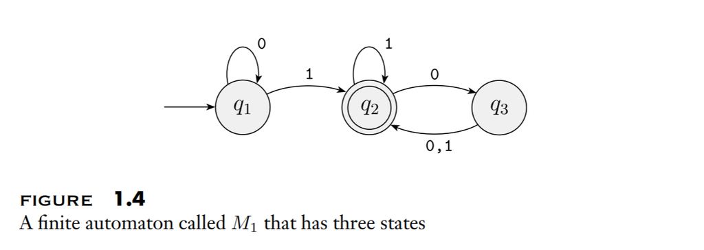

- This is called a **state** diagram
  - It has three **states**, $q_1, q_2, q_3$.
  - $q_1$ is the **starting state**
  - $q_2$ is the **accept state**, hence the double circle around it
  - The arrows are called **transitions**
- Autamota create an output that is either **accept** or **reject**
  - The output is accept if the string ends in the accept state
    - We say that the string is accepted
- The above state diagram reads in the following way on input string $1101$:

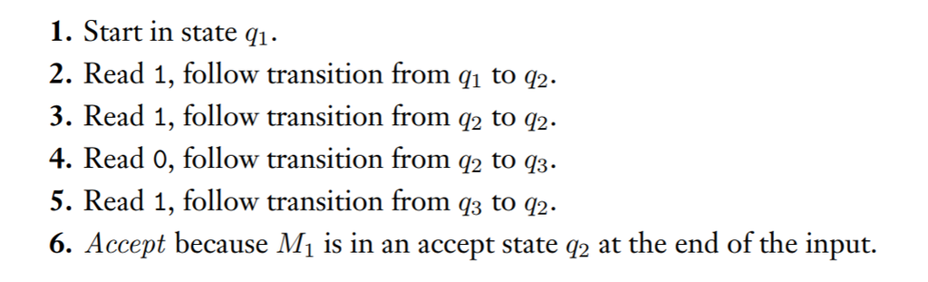

- Formal definition:

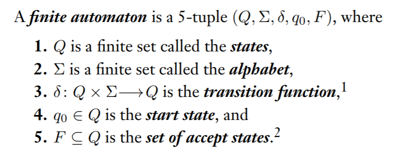

- The formal definition of the above state diagram is as follows:

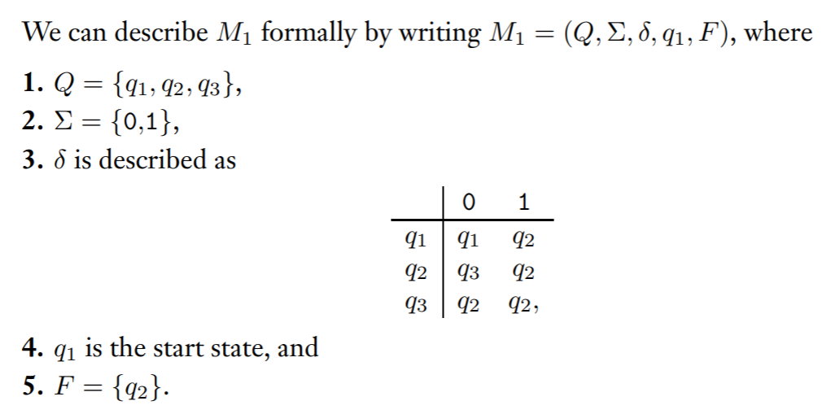

- Say that $A$ is a set of all of the strings that is accepted by the finite automaton (or machine) $M$.
  - It is said that $A$ is the **language** of the machine in this case and is written as $L(M) = A$.
  - This is verbalized as $M$ **recognizes** $A$ or $M$ **accepts** $A$.
- A machine can accept many strings but will always recognize only one language
  - A machine that accepts no strings still accepts a language, the **empty language**, $\varnothing$
- In the above example, the language would be:  
  $A = \left\{w | w ~\text{contains at least one 1 and an even number of 0s follow the last 1}\right\}$

#### Designing a Finite Automaton

- The goal is to design a machine that will recognize the language $L = \left\{w | w ~\text{contains an odd number of ones}\right\}~$ in the alphabet $\Sigma = \left\{0, 1\right\}$
- All you need to remember is whether the number of ones seen sof ar is even or odd
  - If you read a $1$, flip states. If you read a $0$, stay in the same state
- Two states needed:

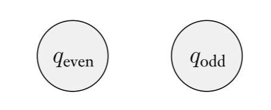

- Assign transitions by seeing how to go from one possibility to another based on reading a symbol
  - i.e. if you’re in $q_{even}$ and you read a $1$, go to $q_{odd}$ and vice versa
  - if you’re in either state and you read a $0$, stay there

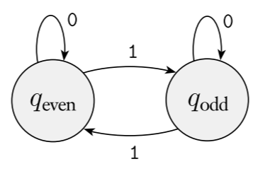

- Determine which will be your starting and accepting states.
  - You want to have an odd number of ones so the accept state should be $q_{odd}$
  - The starting state should be $q_{even}$ because having no ones would be an even number of them.

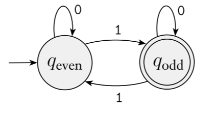

### Regular Operators

- Like a tool for regular languages, **regular operators** are operations specifically designed for manipulating regular languages
- Regular languages are defined as follows:
  - Let $A$ and $B$ be languages. We define regular operations **union**, **concatenation**, and **star** as:
    - **Union**: $A \cup B = \left\{x | x \in A ~\text{or}~ x \in B\right\}$
    - **Concatenation**: $A\circ B = \left\{xy | x \in A ~\text{and}~ y \in B\right\}$
    - **Star**: $A^* = \left\{x_1x_2...x_k | k \geq 0 ~\text{and each}~ x_i \in A\right\}$
- Union takes all of the strings in both $A$ and $B$ and lumps them together into one language
- Concatenation attaches a string from $A$ onto the front of a string from $B$ in all possible ways to get the strings in the new language
- Star is a **unary operation** that attaches any number of strings in $A$ together to get a string in a new language. It includes $0$ as a possibility and the empty string $\lambda$ is always a member of the language
- An example of how these operators work is as follows:

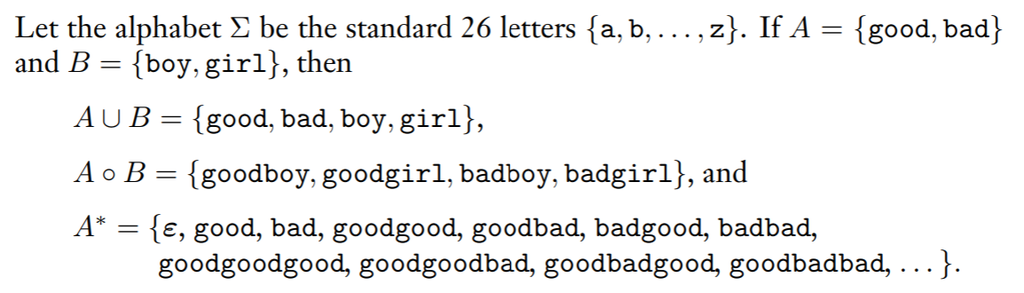

#### Closure Under Regular Operators

- **Union**: The class of regular languages is closed under the union operation. In other words, if $A_1$ and $A_2$ are regular languages, then so is $A_1 \cup A_2$
  - Proof: Let $M_1$ recognize $A_1$ where $M_1 = \left(Q_1, \Sigma, \delta_1, q_1, F_1\right)$ and $M_2$ recognize $A_2$ where $M_2 = \left(Q_2, \Sigma, \delta_2, q_2, F_2\right)$
    - Construct $M$ to recognize $A_1 \cup A_2$ where $M = \left(Q, \Sigma, \delta, q_o, F\right)$
      - $Q = \left\{(r_1, r_2) | r_1 \in Q_1 ~\text{and}~ r_2 \in Q_2\right\}$  
        This is the **cartesian product** of sets $Q_1$ and $Q_2$, written as $Q_1 \times Q_2$. It is the set of all pairs of states, the first from $Q_1$ and the second from $Q_2$.
      - $\Sigma$, the alphabet, is the same as in $M_1$ and $M_2$. In this theorem (and in all subsequent similar theorems) we assume for simplicity that both $M_1$ and $M_2$ have the same input alphabet $\Sigma$. The theorem remains true if they have different alphabets, you would just have to modify the proff to let $\Sigma = \Sigma_1 \cup \Sigma_2$
      - $\delta$, the transition function, is defined as follows:  
        For each $(r_1, r_2) \in Q$ and each $a \in \Sigma$, let  
        $\delta((r_1, r_2), a) = \left(\delta_1(r_1, a), \delta_2(r_2, a)\right)$  
        Hence $\delta$ gets a state of $M$ (which is actually a pair of states from $M_1$ and $M_2$), together with an input symbol, and returns $M's$ next state.
      - $q_o$ is the pair $(q_1, q_2)$
      - $F$ is the set of paris in which either member is an accept state of $M_1$ or $M_2$. We can write it as  
        $F = \left\{(r_1, r_2) | r_1 \in F ~\text{or}~ r_2 \in F_2\right\}$  
        This expression is the same as $F = (F_1 \times Q_2) \cup (Q_1 \times F_2)$
  - This is the entire construction for the machine $M$ that recognizes $A_1 \cup A_2$
- **Concatenation**: The class of regular languages is closed under the concatenation operation. In other words, if $A_1$ and $A_2$ are regular languages then so is $A_1 \circ A_2$.
  - This is similar to the proof above. However, instead of constructing a machine that will accept if either $M_1$ or $M_2$ accept, it must accept if the input can be broken into two pieces, one of which will be accepted by $M_1$ and the other which will be accepted by $M_2$. The issue arises with not knowing where to break the input; we need nondeterminism to solve this (jump to NFAs).

### DFAs

- DFA stands for **deterministic finite automaton**
- Has exactly one exiting transition arrow for each symbol in the alphabet and does not allow for $\lambda$ transitions
- The transition function takes a state and an input symbol and produces the next state

### NFAs

- NFA stands for **nondeterministic finite automaton**
- In a nondeterministic machine, several choices may exist for the next state at any point
- Compared to the automaton shown above, NFAs have additional features such as $\lambda$ transitions and the allowance of not having an arrow for each symbol in the alphabet

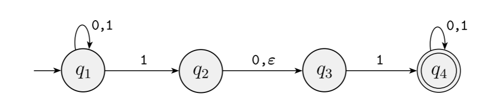

- When there is an input that has multiple ways to proceed, the machine starts running all choices in parallel; each copy of the machine takes a different way to proceed
  - The splitting continues if the copy comes across another need to split
  - The copies of the machine die if there are no more options for it to proceed
  - If **any** of the copies accept, the entire NFA accepts
- You can see the difference between NFAs and DFAs in a tree structure

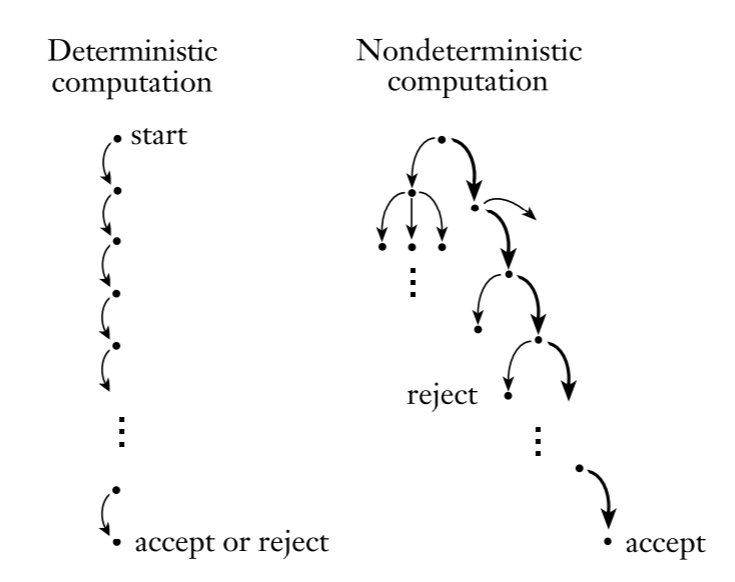

- The example NFA above would have a tree that looks like the following for an input string 010110

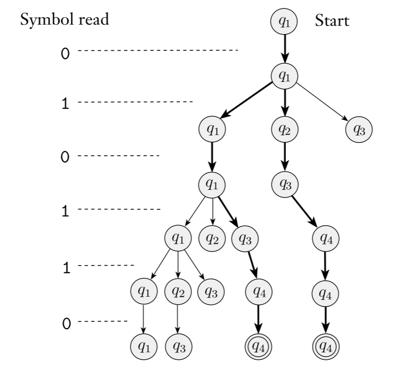

[figure not shown]

- Formal Definition
  - Different from a DFA in the fact that the transition function takes a state and an input symbol **or the empty string** and produces the **set of possible next states**
  - An NFA is a 5-tuple $(Q, \Sigma, \delta, q_o, F)$ where:
    - $Q$ is a finite set of states
    - $\Sigma$ is a finite alphabet
    - $\delta: Q \times \Sigma_{\lambda} \to P(Q)$ is the transition function
    - $q_o \in Q$ is the start state
    - $F \subset Q$ is the set of accept states
  - Below is the formal definition of the above NFA example

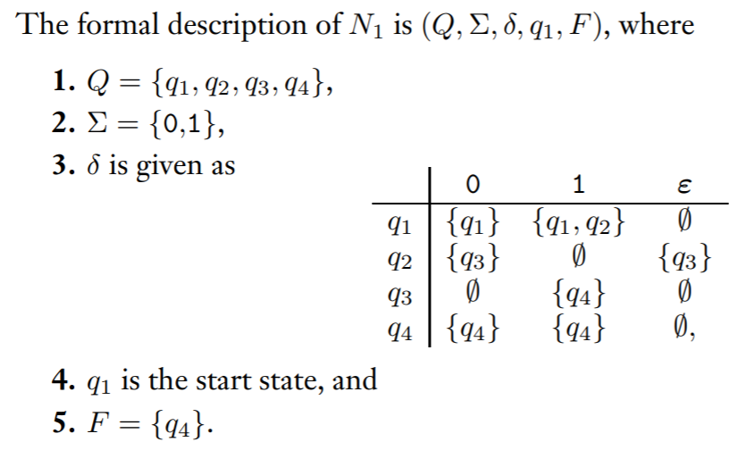

#### Construct DFA from NFA

- Consider the following NFA, $N_4$

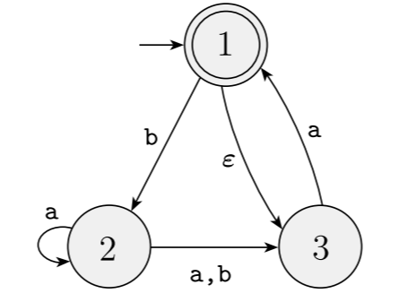

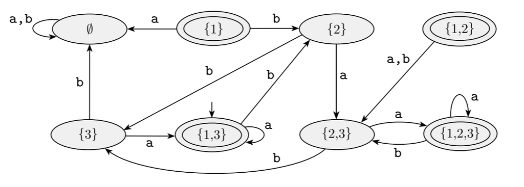

- You can remove the unnecessary states
  - Unnecessary states are those that do not have an arrow going **into** them

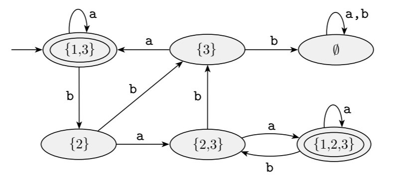

#### Closure Under the Regular Operations

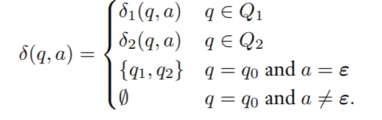

- **Concatenation**: The class of regular languages is closed under the concatenation operation
  - Proof: Let $N_1 = (Q_1, \Sigma, \delta_1, q_1, F_1)$ recognize $A_1$ and $N_2 = (Q_2, \Sigma, \delta_2, q_2, F_2)$ recognize $A_2$  
    Construct $N = (Q, \Sigma, \delta, q_1, F_2)$ to recognize $A_1 \circ A_2$
    - $Q = Q_1 \cup A_2$  
      The states of $N$ are all the states of $N_1$ and $N_2$
    - The state $q_1$ is the sae as the start state of $N_1$
    - The accept states $F_2$ are the same as the accept states of $N_2$
    - Define $\delta$ so that for any $q \in Q$ and any $a \in \Sigma_{\lambda}$

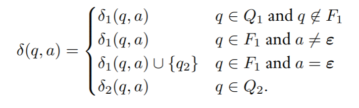

- **Star**: The class of regular languages is closed under the star operation
  - Proof: Let $N_1 = (Q_1, \Sigma, \delta_1, q_1, F_1)$ recognize $A_1$  
    Construct $N = (Q, \Sigma, \delta, q_o, F)$ recognize $A_1^*$
    - $Q = \{q_o\} \cup Q_1$  
      The states of $N$ are the states of $N_1$ plus a new start state
    - The state $q_o$ is the new start state
    - $F = \{q_o\} \cup F_1$  
      the accept states are the old accept states plus the new start state
    - Define $\delta$ so that for any $q \in Q$ and any $a \in \Sigma_{\lambda}$

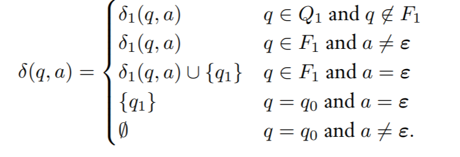

### Regular Expressions

- A **regular expression** is the use of regular operations to build up expressions describing languages
  - An example is $(0 \cup 1)0^*$
- Arithmetic expressions such as $(5 + 3) \times 4$ result in a numeric value, $32$ for this specific example. Regular expressions have a similar result; their value is a language
  - You get the language by dissolving the regular expression into parts
- From the above example:
  - $0$ and $1$ are shorthand for $\{0\} ~\text{and}~ \{1\}$, respectively. This means that $(0 \cup 1)$ translates to $(\{0\} \cup \{1\})$ which is part of the language $\{0, 1\}$
  - The part $0^*$ is shorthand for $\{0^*\}$ which means that its value is the language of all strings containing any number of $0s$
  - Lastly, similar to the $\times$ expression in arithmetic expressions, the $\circ$ operation is often implied in regular expressions. It is assumed that $(0 \cup 1)0^*$ translates to $(0 \cup 1) \circ 0^*$
    - The concatenation, as discussed previously, attaches the strings to obtain an entire expression
- Formal Definition:
  - Say that $R$ is a **regular expression** if $R$ is:
    - $a$ for some $a \in \Sigma$
    - $\lambda$
    - $\varnothing$
    - $(R_1 \cup R_2)$ where $R_1$ and $R_2$ are regular expressions
    - $(R_1 \circ R_2)$ where $R_1$ and $R_2$ are regular expressions
    - $(R_1^*)$ where $R_1$ is a regular expression
- Order of Operations for Regular Expressions
  - Parenthesis may be omitted in an expression. The order of operations is:
    - Star
    - Concatenation
    - Union
- $R^+$ is shorthand for $RR^*$
  - In other words, where $R*$ contains all of the strings containing any number of concatenations of $R$ including $0$, $R^+$ must contain at least one or more concatenations of $R$
- Concatenating any set to $\varnothing$ yields $\varnothing$

#### Equivalence with Finite Automata

- A language is regular iff some regular expression describes it
  - This will be broken into two steps due to the iff, first we will look at:  
    If a language is described by a regular expression, then it is regular
  - Proof: Convert $R$ into an NFA $N$. Consider the six cases in the formal definition of regular expressions
  - $R = a$ for some $a \in \Sigma$. Then $L(R) = \{a\}$, and the following NFA recognizes $L(R)$

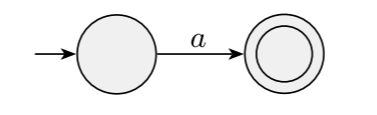

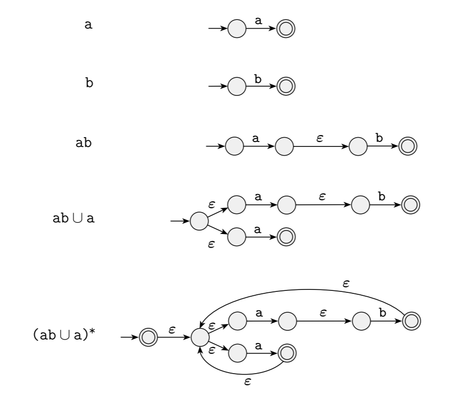

### GNFAs

- GNFA stands for **generalized nondeterministic finite automata**
- GNFAs are simply NFAs where the transition arrows may have regular expressions as labels rather than strictly symbols of the alphabet or $\lambda$
- It reads blocks of symbols from the input, not just one symbol at a time
- It will accept its input if the input causes the GNFA to end in an accepting state

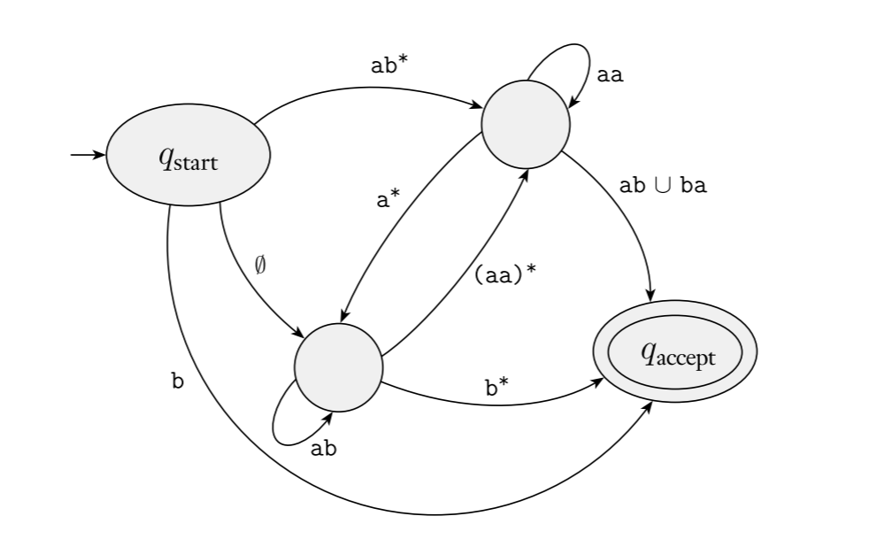

- A GNFA must always meet the following conditions:
  - The start state has transition arrows going to every other state but no arrows coming in from any other state
  - There is only one accept state that has arrows coming in from every other state but no arrows going to any other state. The accept state can not be the same as the start state
  - Except for the start and accept states, one arrow goes from every state to every other state and also from each state to itself
- Converting from a DFA to a GNFA
  - Add a new start state with a $\lambda$ arrow to the old start state
  - Add a new accept state with $\lambda$ arrows coming from the old states
  - If there are any arrows with multiple labels or multiple arrows going between the same two states in the same direction, replace each arrow with one arrow whose label is the union of the previous ones
  - Add $\varnothing$ arrows between states that had no arrows
- GNFA Reductions
  - Because GNFAs must have one start and one accept states, we now that they must have at least two states ($k \geq 2$ when $k$ = number of states)
  - For $k > 2$, we can construct a GNFA with $k - 1$ states
  - We can continue removing states until there are only two
    - The arrow that will go between the start and accept states are equal to the regular expression that is accepted by the GNFA
  - Example:

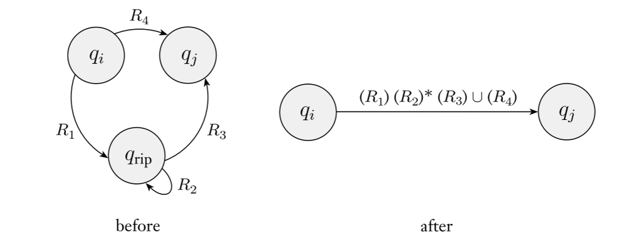

  - The steps for this reduction are:

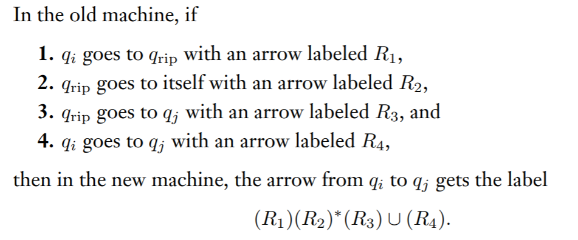

- Formal Definition
  - A generalized nondeterministic finite automaton is a 5-tuple $(Q, \Sigma, \delta, q_{start}, q_{accept})$, where
    - $Q$ is the finite set of states
    - $\Sigma$ is the input alphabet
    - $\delta: (Q - \{q_{accept}\}) \times (Q - \{q_{start}\}) \to R$ is the transition function where $R$ is the collection of all regular expressions over the alphabet $\Sigma$
    - $q_{start}$ is the start state
    - $q_{accept}$ is the accept state

### Pumping Lemma for Regular Languages

- Certain languages can’t be recognized by any finite automaton, for example:  
  $B = \{0^n1^n | n \geq 0\}$
  - When trying to make a DFA for this language, it is seen that you need to remember how many 0’s have been seen so far as it reads input- but the number of 0’s isn’t limited. You will have to keep track of an unlimited number of possibilities- but that can’t be done with a finite number of states
- The Pumping Lemma is a way to prove that languages like these are **not** regular
  - The pumping lemma states that all regular languages have a special property, and that if we can show that a language doesn’t have this property, it is certain that this language is not regular.
  - The property is that all strings in the language can be “pumped” if they are at least as long as the **pumping length**
    - Each string contains a section that can be repeated as many number of times as desired and the resulting string will still be in the language
- Pumping Lemma: The Theorem
  - If $A$ is a regular language, then there is a number $p$ (the pumping length) where if $s$ is any string in $A$ of length at least $p$, then $s$ may be divided into $s = xyz$, such that:
    - For each $i \geq 0$, $xy^iz \in A$
    - $|y| > 0$
    - $|xy| \leq p$
- Pumping Lemma: The Proof
  - Let $M = (Q, \Sigma, \delta, q_1, F)$ be a DFA recognizing $A$ and $P$ be the number of states in $M$
  - Let $s = s_1s_2...s_n$ be a string in $A$ of length $n$ where $n \geq p$
  - Let $r_1...r_{n+1}$ be the sequence of states that $M$ enters while processing $s$
    - $r_{i+1} = \delta(r_i, s_i)$ for $1 \leq i \leq n$
    - The sequence has length $n+1$, which is at least $p+1$
  - Two of the first $p+1$ elements in the sequence must be the same according to the pigeonhole principle
    - We call these elements $r_j$ and $r_l$
    - $r_l$ occurs among the first $p+1$ places in the squence starting at $r_1$ and therefore we can say that $l \leq p + 1$
  - Now let $x = s_1...s_{j-1}, y = s_j...s_{l-1}, ~\text{and}~ z = s_l...s_n$
    - As $x$ takes $M$ from $r_1$ to $r_j$, $y$ takes $M$ from $r_j$ to $r_j$, and $z$ takes $M$ from $r_j$ to $r_{n+1}$, which is an accept state
    - $M$ must accept $xy^iz$ for $i \geq 0$
    - We know that $j \neq l$, so $|y| > 0$
    - We also know that $l \leq p + 1$, so $|xy| \leq p$
  - Thus, all conditions for the pumping lemma are satisfied
- How to use the pumping lemma
  - It is used to prove that a language is not regular, you should use proof by contradiction
    - First, assume that $B$ is a regular language
    - State that because $B$ is regular, it has a pumping length $p$ and that all strings in $B$ that at least length $p$ can be pumped up or pumped down
    - Find a string $s$ in $B$ that has length $p$ or greater that can **not** be pumped
    - Show that $s$ can **not** be pumped by considering all ways of dividing $s = xy^iz$
      - For each division, show that there is a value of $i$ such that $xy^iz \notin B$
  - The final conclusion should be that the existance of $s$ contradicts the pumping lemma if $B$ were regular, and therefore $B$ is not regular

# Context Free Languages

- **Context free languages** are the collection of languages associated with context free grammars
- They include all of the regular languages as well as many new languages

### Context Free Grammars

- A powerful method of describing languages
- They can describe features that have a recursive structure
- They have a component called a **parser** which can get the meaning of a program prior to compilation or execution
- A context free grammar looks like:

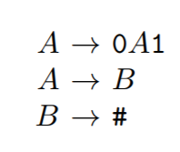

- Each line in the CFG represents a **substitution rule**, also known as a **production**
- The symbol to the left of the arrow is called a **variable** and the strings to the right of the arrow are called **terminals**
  - Variables are often represented by capital letters
  - The terminals are similar to an input alphabet an often represented by lower case letters, numbers, or special symbols
  - One variable is designated as the **start variable** which usually occurs on the leftmost side of the topmost rule. In the above example, $A$ is the start variable
- You can use grammars to generate strings of a language by:
  - Write down the start variable
  - Find a variable that is written down and a rule that starts with that variable. Replace the written down variable with the right-hand side of that rule
  - Repeat step 2 until no variables remain
    - For example, the CFG above creates the string $000\#111$
  - The sequence of substitutions to obtain this string is called a **derivation**
    - $A \rightarrow 0A1 \rightarrow 00A11 \rightarrow 000A111 \rightarrow 000B111 \rightarrow 000\#111$
    - You can also represent this with a **parse tree**

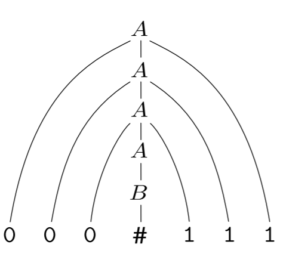

  - All strings generated this way create the **language of the grammar* written as $L(G)$
    - The above example creates a language of $\{0^n\#1^n|n \geq 0\}$
- Formal Definition:
  - A context free grammar is a 4-tuple $(V, \Sigma, R, S)$ where
    - $V$ is a finite set called the variables
    - $\Sigma$ is a finite set called the terminals
    - $R$ is a finite set of rules
    - $S \in V$ is the start variable
  - In the example grammar:
    - $V = \{A, B\}$
    - $\Sigma = \{0, 1, \#\}$
    - $S = A$
    - $R$ is the collection of the three rules
- Designing a context free grammar
  - Take the language $L = \{0^n1^n | n \geq 0\} \cup \{1^n0^n | n \geq 0\}$, construct the grammar  
    $S_1 \to 0S_11 | \lambda$ for the first half of the union. Then construct the grammar $S_2 \to 1S_20 | \lambda$ for the second half of the union
  - Add the rule $S \to S_1 | S_2$ to give the final grammar:

  $$S \to S_1 | S_2\\
  S_1 \to 0S_11|\lambda\\
  S_! \to 1S_20 | \lambda$$
- Designing a context free grammar from a DFA
  - Make a variable $R_i$ for each state $q_i$ in the DFA
  - Add the rule $R_i \to aR_j$ to the CFG if $\delta(q_i, a) = q_j$ is the transition in the DFA
  - Add the rule $$R_i \to \lambda$ if $q_i$ is an accept state of the DFA
  - Make $R_o$ the start variable of the grammar, where $q_o$ is the start state of the machine
  - Verify that the CFG generates the same language as the DFA recognizes
- Ambiguity
  - A string that can be derived more than one way in the grammar is derived **ambiguously**
  - If a string is generated ambiguously, then the grammar is **ambiguous**
  - For example, the grammar $\langle\text{EXPR}\rangle \to \langle\text{EXPR}\rangle + \langle\text{EXPR}\rangle | \langle\text{EXPR}\rangle \times \langle\text{EXPR}\rangle | \left(\langle\text{EXPR}\rangle\right)| a$  
    generates the string $a+a \times a$ ambiguously. The following parse trees demonstrate two ways to get this string:

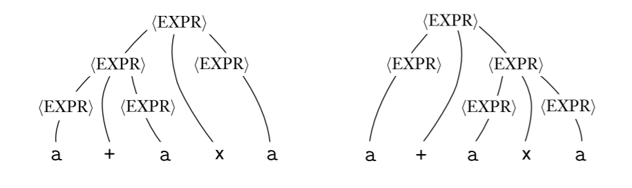

  - Ambiguity means two different parse trees, **not** two different derivations
    - A **leftmost derivation** is a derivation of a string where at every step, the leftmost remaining variable is the one replaced
  - Defintion 2.7: A string $w$ is derived ambiguously in a context-free grammar $G$ if it has two ore more different leftmost derivations. Grammar $G$ is ambiguous if it generates some string ambiguously

#### Chomsky Normal Form

- chomp chomp
- Useful in giving algorithms for working with context free grammars
- Formal definition:
  - A context free grammar is in chomsky normal form if every rule is of the form  
    $A \to BC$  
    $A \to a$  
    where $a$ is any terminal and $A, B$, and $C$ are any variables- except that $B$ and $C$ may not be the start variable. In addition, we permit the rule $S \to \lambda$ where $S$ is the start variable
- Theorem: A context free language is generated by a context-free grammar in Chomsky Normal Form
- Proof: First, add a new start variable $S_o$ and the rule $S_o \to S$
  - Take care of all $\lambda$ rules
    - We remove a $\lambda$ rule $A \to \lambda$ where $A$ is not the start variable
    - For each $A$ that appears on the right hand side of a rule, we add a new rule with that occurence deleted
      - For example, if $R \to uAv$ is a rule we add the rule $R \to uv$. It is done for each **occurence** of $A$, so the rule $R \to uAvAw$ causes us to add $R \to uvAw$, $R \to uAvw$, and $R \to uvw$
    - If we have the rule $R \to A$, we had $R \to \lambda$ unless we had previously removed the rule $R \to \lambda$
    - These steps are repeated until all $\lambda$ rules are eliminated not including the starting variable
  - Handle all unit rules
    - Remove a unit rule $A \to B$
    - Whenever $B \to u$ appears, add the rule $A \to u$ unless it was a unit rule previously removed
    - Repeat these steps until all unit rules are eliminated
  - Convert the remaining rules into the proper form
    - Replace each rule $A \to u_1u_2...u_k$ where $k \geq 3$ and each $u_i$ is a variable or terminal symbol, with the rules $A \to u_1A_1, A_1 \to u_2A_2, A_2 \to u_3A_3, ..., A_{k-2} \to u_{k-1}u_j$
      - The $A's$ are nrew variables. We replace any terminal $u$ in the preceding rule(s) with a new variable $U_i \to u_i$

### Pushdown Automaton

- **Pushdown Automata** is a class of machines recognizing context-free languages that can be useful by allowing us insight into the power of context free grammars
- Similar to NFAs but have an extra component called a **stack**
  - The stack provides additional memory beyond the finite amount available in an NFA
  - Allows for recognition of nonregular languages
- Equivalent in power to CFGs
  - Two options for proving that a language is context free: either give a CFG or PDA
- PDA Schematic:

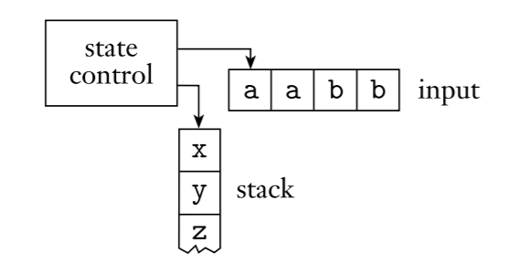

- A PDA can write symbols on the stack and read them back later
  - Writing a symbol is “pushing it down” because it pushes down all of the other symbols on the stack. Any symbol on the top of the stack can be read and removed, the remaining symbols all move up
  - LIFO (last in first out) storage
- A PDA can recognize the language $\{0^n1^n | n \geq 0\}$ because the stack allows it to store the number of 0’s that have been seen. If you recall from earlier, we mentioned that finite automaton can not recognize this language due to limited memory
- Formal Definition: A pushdown automaton is a 6-tuple $(Q, \Sigma, \Gamma, \delta, q_o, F)$ where $Q, \Sigma, \Gamma, F$ are all finite sets, and:
  - $Q$ is the set of states
  - $\Sigma$ is the input alphabet
  - $\Gamma$ is the stack alphabet
  - $\delta: Q \times \Sigma_{\lambda} \times \Gamma_{\lambda} \to P(Q \times \Gamma_{\lambda})$ is the transition function,
  - $q_o \in Q$ is the start state
  - $F \subseteq Q$ is the set of accept states
- The below PDA recognizes the language $K = \{o^n1^n | n \geq 0\}$:

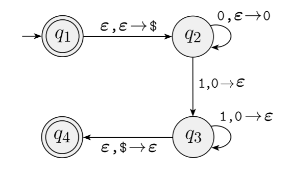